# EasyVisa Project

## Context:

Business communities in the United States are facing high demand for human resources, but one of the constant challenges is identifying and attracting the right talent, which is perhaps the most important element in remaining competitive. Companies in the United States look for hard-working, talented, and qualified individuals both locally as well as abroad.

The Immigration and Nationality Act (INA) of the US permits foreign workers to come to the United States to work on either a temporary or permanent basis. The act also protects US workers against adverse impacts on their wages or working conditions by ensuring US employers' compliance with statutory requirements when they hire foreign workers to fill workforce shortages. The immigration programs are administered by the Office of Foreign Labor Certification (OFLC).

OFLC processes job certification applications for employers seeking to bring foreign workers into the United States and grants certifications in those cases where employers can demonstrate that there are not sufficient US workers available to perform the work at wages that meet or exceed the wage paid for the occupation in the area of intended employment.

## Objective:

In FY 2016, the OFLC processed 775,979 employer applications for 1,699,957 positions for temporary and permanent labor certifications. This was a nine percent increase in the overall number of processed applications from the previous year. The process of reviewing every case is becoming a tedious task as the number of applicants is increasing every year.

The increasing number of applicants every year calls for a Machine Learning based solution that can help in shortlisting the candidates having higher chances of VISA approval. OFLC has hired your firm EasyVisa for data-driven solutions. You as a data scientist have to analyze the data provided and, with the help of a classification model:

- Facilitate the process of visa approvals.
- Recommend a suitable profile for the applicants for whom the visa should be certified or denied based on the drivers that significantly influence the case status.

## Data Description

The data contains the different attributes of the employee and the employer. The detailed data dictionary is given below.

- case_id: ID of each visa application
- continent: Information of continent the employee
- education_of_employee: Information of education of the employee
- has_job_experience: Does the employee has any job experience? Y= Yes; N = No
- requires_job_training: Does the employee require any job training? Y = Yes; N = No
- no_of_employees: Number of employees in the employer's company
- yr_of_estab: Year in which the employer's company was established
- region_of_employment: Information of foreign worker's intended region of employment in the US.
- prevailing_wage: Average wage paid to similarly employed workers in a specific occupation in the area of intended employment. The purpose of the prevailing wage is to ensure that the foreign worker is not underpaid compared to other workers offering the same or similar service in the same area of employment.
- unit_of_wage: Unit of prevailing wage. Values include Hourly, Weekly, Monthly, and Yearly.
- full_time_position: Is the position of work full-time? Y = Full Time Position; N = Part Time Position
- case_status: Flag indicating if the Visa was certified or denied

## Importing necessary libraries and data

```python
import pandas as pd
import matplotlib.pyplot as plt
import numpy as np
import seaborn as sns

# To build linear model for statistical analysis and prediction
import statsmodels.stats.api as sms
from statsmodels.stats.outliers_influence import variance_inflation_factor
import statsmodels.api as sm
from statsmodels.tools.tools import add_constant

# Library to split data
from sklearn.model_selection import train_test_split

# To get diferent metric scores
from sklearn import metrics
from sklearn.metrics import accuracy_score, roc_curve, confusion_matrix, roc_auc_score

# Decision Tree, Bagging and Random Forest packages
from sklearn.tree import DecisionTreeClassifier
from sklearn import tree
from sklearn.ensemble import BaggingClassifier, RandomForestClassifier
from sklearn.model_selection import GridSearchCV

%load_ext nb_black

# Ignores Warnings
import warnings

warnings.filterwarnings("ignore")

# Boosting Packages
from sklearn.ensemble import AdaBoostClassifier, GradientBoostingClassifier
from xgboost import XGBClassifier
```

```python
# Importing the dataset
df = pd.read_csv("EasyVisa.csv")
df.head(20)
```

|  | case_id | continent | education_of_employee | has_job_experience | requires_job_training | no_of_employees | yr_of_estab | region_of_employment | prevailing_wage | unit_of_wage | full_time_position | case_status |
| --- | --- | --- | --- | --- | --- | --- | --- | --- | --- | --- | --- | --- |
| 0 | EZYV01 | Asia | High School | N | N | 14513 | 2007 | West | 592.2029 | Hour | Y | Denied |
| 1 | EZYV02 | Asia | Master's | Y | N | 2412 | 2002 | Northeast | 83425.6500 | Year | Y | Certified |
| 2 | EZYV03 | Asia | Bachelor's | N | Y | 44444 | 2008 | West | 122996.8600 | Year | Y | Denied |
| 3 | EZYV04 | Asia | Bachelor's | N | N | 98 | 1897 | West | 83434.0300 | Year | Y | Denied |
| 4 | EZYV05 | Africa | Master's | Y | N | 1082 | 2005 | South | 149907.3900 | Year | Y | Certified |
| 5 | EZYV06 | Asia | Master's | Y | N | 2339 | 2012 | South | 78252.1400 | Year | Y | Certified |
| 6 | EZYV07 | Asia | Bachelor's | N | N | 4985 | 1994 | South | 53635.3900 | Year | Y | Certified |
| 7 | EZYV08 | North America | Bachelor's | Y | N | 3035 | 1924 | West | 418.2298 | Hour | Y | Denied |
| 8 | EZYV09 | Asia | Bachelor's | N | N | 4810 | 2012 | Midwest | 74362.1900 | Year | Y | Certified |
| 9 | EZYV10 | Europe | Doctorate | Y | N | 2251 | 1995 | South | 67514.7600 | Year | Y | Certified |
| 10 | EZYV11 | Asia | Master's | N | N | 2465 | 2004 | Midwest | 83588.5600 | Year | Y | Certified |
| 11 | EZYV12 | Asia | High School | Y | N | 4069 | 2005 | Northeast | 70813.0900 | Year | Y | Denied |
| 12 | EZYV13 | Asia | Bachelor's | Y | N | 123876 | 1963 | Northeast | 28663.0500 | Year | Y | Certified |
| 13 | EZYV14 | Asia | Bachelor's | Y | N | 1652 | 2007 | Midwest | 107196.0300 | Year | Y | Certified |
| 14 | EZYV15 | Asia | Master's | Y | Y | 15756 | 2006 | South | 220081.7300 | Year | Y | Certified |
| 15 | EZYV16 | Asia | High School | Y | N | 4897 | 1987 | West | 74108.0200 | Year | Y | Denied |
| 16 | EZYV17 | Europe | Master's | Y | N | 76638 | 1991 | Midwest | 3706.7900 | Year | Y | Certified |
| 17 | EZYV18 | Asia | Master's | Y | N | 2747 | 2001 | West | 16132.6100 | Year | Y | Certified |
| 18 | EZYV19 | Africa | Master's | Y | N | 4743 | 2004 | Midwest | 150441.1300 | Year | Y | Certified |
| 19 | EZYV20 | Asia | Doctorate | N | N | 843 | 1972 | Midwest | 79948.1200 | Year | Y | Certified |

## Data Overview

- Observations
- Sanity checks

```python
df.shape
```

```
(25480, 12)
```

```python
# Checking for duplicate values
df.duplicated().sum()
```

```
0
```

```python
# Checking for null values
df.isnull().sum()
```

```
case_id                  0
continent                0
education_of_employee    0
has_job_experience       0
requires_job_training    0
no_of_employees          0
yr_of_estab              0
region_of_employment     0
prevailing_wage          0
unit_of_wage             0
full_time_position       0
case_status              0
dtype: int64
```

```python
df.info()
```

```
<class 'pandas.core.frame.DataFrame'>
RangeIndex: 25480 entries, 0 to 25479
Data columns (total 12 columns):
 #   Column                 Non-Null Count  Dtype
---  ------                 --------------  -----
 0   case_id                25480 non-null  object
 1   continent              25480 non-null  object
 2   education_of_employee  25480 non-null  object
 3   has_job_experience     25480 non-null  object
 4   requires_job_training  25480 non-null  object
 5   no_of_employees        25480 non-null  int64
 6   yr_of_estab            25480 non-null  int64
 7   region_of_employment   25480 non-null  object
 8   prevailing_wage        25480 non-null  float64
 9   unit_of_wage           25480 non-null  object
 10  full_time_position     25480 non-null  object
 11  case_status            25480 non-null  object
dtypes: float64(1), int64(2), object(9)
memory usage: 2.3+ MB
```

```python
df.describe()
```

|  | no_of_employees | yr_of_estab | prevailing_wage |
| --- | --- | --- | --- |
| count | 25480.000000 | 25480.000000 | 25480.000000 |
| mean | 5667.043210 | 1979.409929 | 74455.814592 |
| std | 22877.928848 | 42.366929 | 52815.942327 |
| min | -26.000000 | 1800.000000 | 2.136700 |
| 25% | 1022.000000 | 1976.000000 | 34015.480000 |
| 50% | 2109.000000 | 1997.000000 | 70308.210000 |
| 75% | 3504.000000 | 2005.000000 | 107735.512500 |
| max | 602069.000000 | 2016.000000 | 319210.270000 |

- A minimum of -26 employees doesn't make sense, let us explore this statistic further

```python
# Filtering for data where employee count is less than zero and printing the dataframe rows/columns
print(df[df["no_of_employees"] < 0].shape)
df[df["no_of_employees"] < 0].head()
```

```
(33, 12)
```

|  | case_id | continent | education_of_employee | has_job_experience | requires_job_training | no_of_employees | yr_of_estab | region_of_employment | prevailing_wage | unit_of_wage | full_time_position | case_status |
| --- | --- | --- | --- | --- | --- | --- | --- | --- | --- | --- | --- | --- |
| 245 | EZYV246 | Europe | Master's | N | N | -25 | 1980 | Northeast | 39452.99 | Year | Y | Certified |
| 378 | EZYV379 | Asia | Bachelor's | N | Y | -11 | 2011 | Northeast | 32506.14 | Year | Y | Denied |
| 832 | EZYV833 | South America | Master's | Y | N | -17 | 2002 | South | 129701.94 | Year | Y | Certified |
| 2918 | EZYV2919 | Asia | Master's | Y | N | -26 | 2005 | Midwest | 112799.46 | Year | Y | Certified |
| 6439 | EZYV6440 | Asia | Bachelor's | N | N | -14 | 2013 | South | 103.97 | Hour | Y | Denied |

- There are 33 entries with negative employee numbers, these only represent a very small amount of the total dataset so removing these entires will not greatly affect the final analysis

```python
# Removing the anomalous data and checking the statistical summary again
df = df[df["no_of_employees"] > 0]
df.describe()
```

|  | no_of_employees | yr_of_estab | prevailing_wage |
| --- | --- | --- | --- |
| count | 25447.000000 | 25447.000000 | 25447.000000 |
| mean | 5674.415334 | 1979.394506 | 74468.281479 |
| std | 22891.842245 | 42.385932 | 52822.177370 |
| min | 12.000000 | 1800.000000 | 2.136700 |
| 25% | 1025.000000 | 1976.000000 | 34039.210000 |
| 50% | 2112.000000 | 1997.000000 | 70312.500000 |
| 75% | 3506.500000 | 2005.000000 | 107739.505000 |
| max | 602069.000000 | 2016.000000 | 319210.270000 |

### Section Summary:

- There are no null or duplicated values in the dataset
- The datatypes and stastical summary makes sense aside from number of employees
- The minimum number of employees were negative and upon filtering, 33 rows were identified to have negative employees entered
- Without domain knowledge of whether the negatives were added upon accident or not, the safest route was excluding these rows from our analysis

## Exploratory Data Analysis (EDA)

- EDA is an important part of any project involving data.
- It is important to investigate and understand the data better before building a model with it.
- A few questions have been mentioned below which will help you approach the analysis in the right manner and generate insights from the data.
- A thorough analysis of the data, in addition to the questions mentioned below, should be done.

**Leading Questions**:

1. Those with higher education may want to travel abroad for a well-paid job. Does education play a role in Visa certification?
2. How does the visa status vary across different continents?
3. Experienced professionals might look abroad for opportunities to improve their lifestyles and career development. Does work experience influence visa status?
4. In the United States, employees are paid at different intervals. Which pay unit is most likely to be certified for a visa?
5. The US government has established a prevailing wage to protect local talent and foreign workers. How does the visa status change with the prevailing wage?

### [1] What is the relationship between Employee Education and Visa Case Status

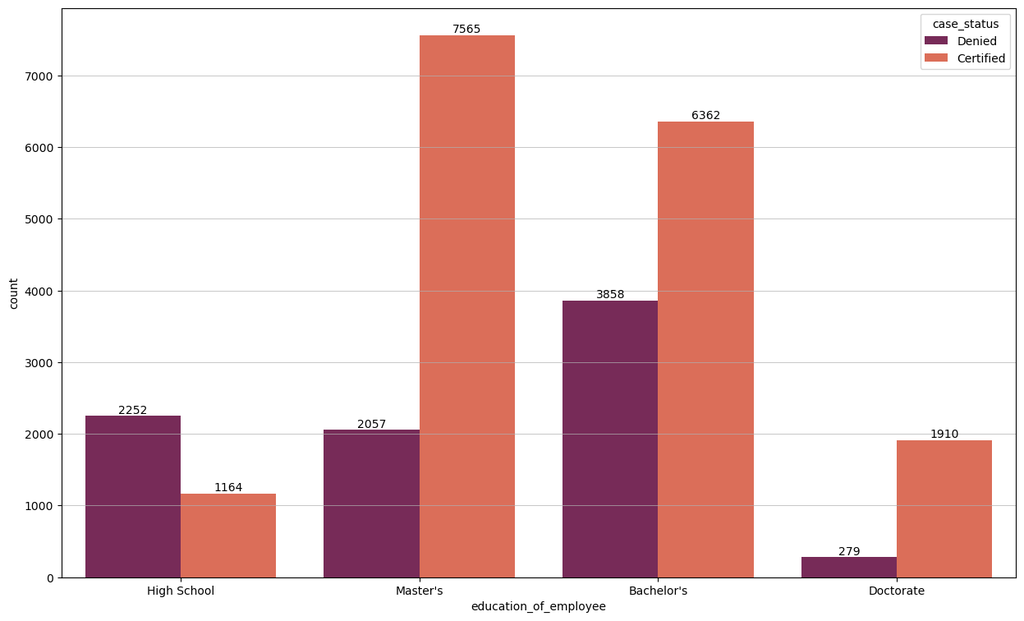

```python
# Creating a countplot of whether the emnployee's visa was accepted or not according to their level of education
plt.figure(figsize=(15, 9))
fig1 = sns.countplot(
    data=df, x="education_of_employee", hue="case_status", palette="rocket"
)

fig1.bar_label(fig1.containers[0], label_type="edge")
fig1.bar_label(fig1.containers[1], label_type="edge")

plt.grid(axis="y", linewidth=0.5)
```

```python
# Creating a dataframe of the above information
Comparison_Frame1 = pd.DataFrame(
    {
        "Education": ["High School", "Bachelors", "Masters", "Doctorate"],
        "Case Acceptance Rate (%)": ["34.07", "62.25", "78.62", "87.25"],
    }
)
Comparison_Frame1
```

|  | Education | Case Acceptance Rate (%) |
| --- | --- | --- |
| 0 | High School | 34.07 |
| 1 | Bachelors | 62.25 |
| 2 | Masters | 78.62 |
| 3 | Doctorate | 87.25 |

- As the education level of the candidate rises, the odds of their Visa being accepted also increase, with the most significant increase being from a High School to Bachelor's education

### [2] Visa Status depending on continent

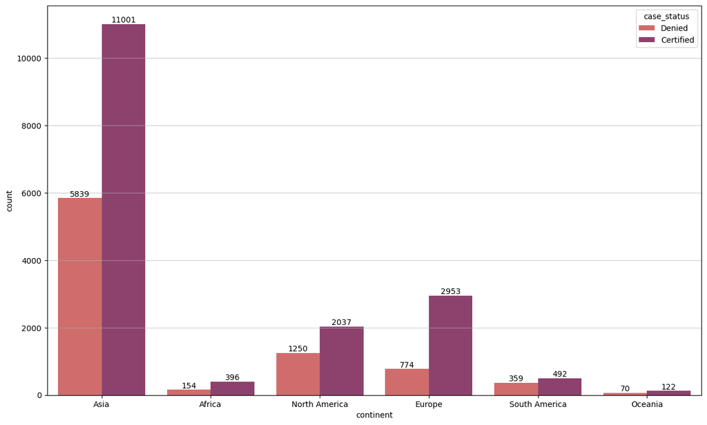

```python
# Creating a countplot of whether the emnployee's visa was accepted or not according to their residing continent
plt.figure(figsize=(15, 9))
fig2 = sns.countplot(data=df, x="continent", hue="case_status", palette="flare")

fig2.bar_label(fig2.containers[0], label_type="edge")
fig2.bar_label(fig2.containers[1], label_type="edge")

plt.grid(axis="y", linewidth=0.5)
```

```python
# Creating a Dataframe of the above information
Comparison_Frame2 = pd.DataFrame(
    {
        "Continent": [
            "Asia",
            "Africa",
            "North America",
            "Europe",
            "South America",
            "Oceania",
        ],
        "Case Acceptance Rate (%)": [
            "65.33",
            "72.00",
            "61.97",
            "79.23",
            "57.81",
            "63.54",
        ],
    }
)
Comparison_Frame2
```

|  | Continent | Case Acceptance Rate (%) |
| --- | --- | --- |
| 0 | Asia | 65.33 |
| 1 | Africa | 72.00 |
| 2 | North America | 61.97 |
| 3 | Europe | 79.23 |
| 4 | South America | 57.81 |
| 5 | Oceania | 63.54 |

```python
df[df["continent"] == "Asia"].shape[0] / df.shape[0] * 100
```

```
66.1767595394349
```

- Most of the candidates reside in Asia (over 66%) and the continent with the highest Visa certification rate is Europe with a nearly 80% case acceptance rate

### [3] Does work experience improve visa acceptance rate

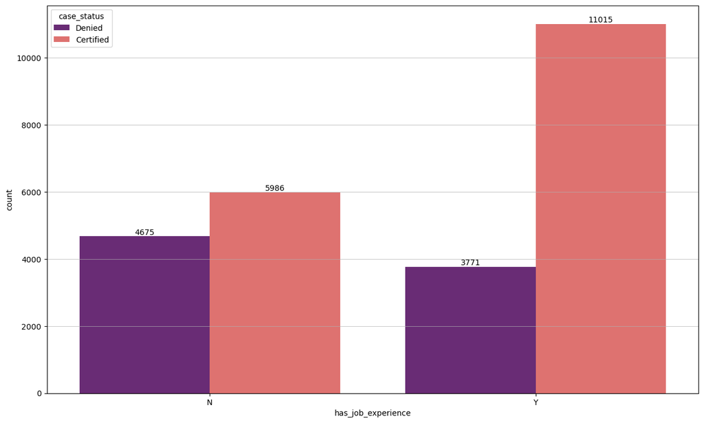

```python
# Creating a countplot of whether the emnployee's visa was accepted or not based on their work experience
plt.figure(figsize=(15, 9))
fig3 = sns.countplot(
    data=df, x="has_job_experience", hue="case_status", palette="magma"
)

fig3.bar_label(fig3.containers[0], label_type="edge")
fig3.bar_label(fig3.containers[1], label_type="edge")

plt.grid(axis="y", linewidth=0.5)
```

```python
# Creating a Dataframe of the above information
Comparison_Frame3 = pd.DataFrame(
    {
        "Has Work Experience": ["No", "Yes"],
        "Case Acceptance Rate (%)": ["56.15", "74.50"],
    }
)
Comparison_Frame3
```

|  | Has Work Experience | Case Acceptance Rate (%) |
| --- | --- | --- |
| 0 | No | 56.15 |
| 1 | Yes | 74.50 |

- Employees with work experience are almost 20% more likely to have their Visa Certified

### [4] Does payment intrervals affect visa acceptance rate

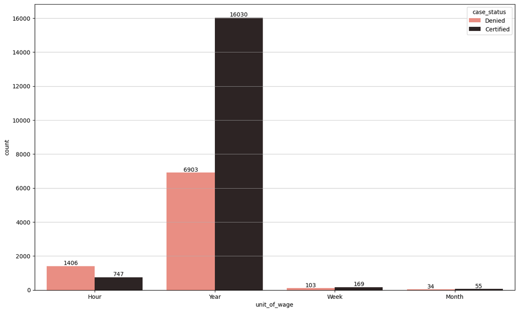

```python
# Creating a countplot of whether the emnployee's visa was accepted or not based on their work experience
plt.figure(figsize=(15, 9))
fig4 = sns.countplot(
    data=df, x="unit_of_wage", hue="case_status", palette="dark:salmon_r"
)

fig4.bar_label(fig4.containers[0], label_type="edge")
fig4.bar_label(fig4.containers[1], label_type="edge")

plt.grid(axis="y", linewidth=0.5)
```

```python
# Creating a Dataframe of the above information
Comparison_Frame4 = pd.DataFrame(
    {
        "Unit of Wage": ["Hour", "Year", "Week", "Month"],
        "Case Acceptance Rate (%)": ["34.70", "69.90", "62.13", "61.80"],
    }
)
Comparison_Frame4
```

|  | Unit of Wage | Case Acceptance Rate (%) |
| --- | --- | --- |
| 0 | Hour | 34.70 |
| 1 | Year | 69.90 |
| 2 | Week | 62.13 |
| 3 | Month | 61.80 |

- While Week and Monthly payment units only have a small amount of data to assess, the employees that get paid Hourly are twice as likely to have their visa denied compared to those paid Yearly
- This finding is interesting as the unit of wage logically shouldn't impact visa certification to this extent, so this variable will be explored further during the modelling stage

### [5] Does prevailing wage affect visa certification rate

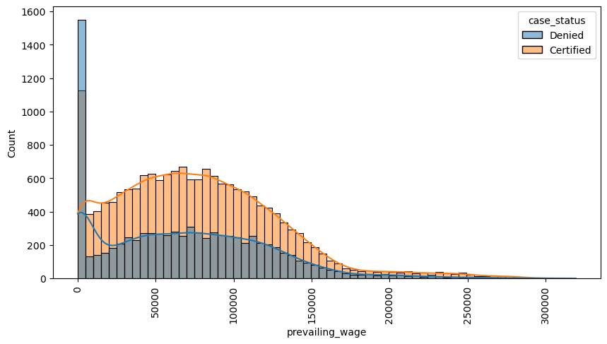

```python
# Creating a Histogram plot showing how Case status varies with Prevailing Wage
plt.figure(figsize=(10, 5))
sns.histplot(data=df, x="prevailing_wage", hue="case_status", kde=True)
plt.xticks(rotation=90)
plt.show()
```

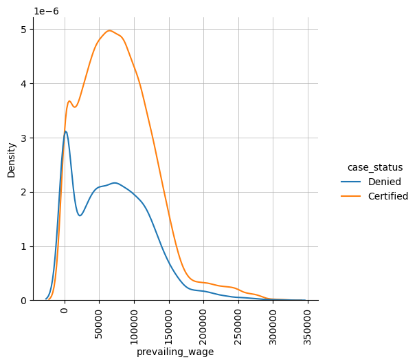

```python
# Creating a KDE plot showing the same with better visualization at the higher end
plt.figure(figsize=(10, 7))
fig5 = sns.displot(data=df, x="prevailing_wage", hue="case_status", kind="kde")

# Rotating x lables and adding gridlines for better visibility
plt.xticks(rotation=90)
plt.grid(axis="y", linewidth=0.5)
plt.grid(axis="x", linewidth=0.5)
plt.show()
```

- While with prevailing wages near zero, there are significantly more denials than acceptances however above 25000, the ratio of Acceptances to Denials increases
- The spikes and troughs in the plots can be due to the wages not being standardized since hourly, weekly and monthly prevailing wage will have a lower visa acceptance rate than a yearly prevailing wage
- This accounts for the large right skew in the plots and also makes sense when taking into account the previous analysis of Hourly wage units having a much lower visa acceptance rate than yearly wage units
- I have attempted making a corrected prevailing wage column, however due to lack of domain knowledge, the number of assumptions about an employee's working hours can lead to an even more skewed plot, therfore it is best to try and recreate the plot using only the yearly wage unit

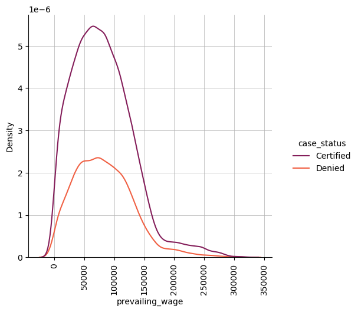

```python
# Creating a KDE plot showing how yearly prevailing wages affect visa acceptance rate
plt.figure(figsize=(10, 7))
fig5 = sns.displot(
    data=df[df["unit_of_wage"] == "Year"],
    x="prevailing_wage",
    hue="case_status",
    kind="kde",
    palette="rocket",
)

# Rotating x lables and adding gridlines for better visibility
plt.xticks(rotation=90)
plt.grid(axis="y", linewidth=0.5)
plt.grid(axis="x", linewidth=0.5)
plt.show()
```

- This graph provides a much clearer and more accurate representation of the dataset, generally across all wages, the ratio of acceptances to denials is about 2.5:1 with slight variation

### Section Summary

- As the education level of the candidate rises, their Visa acceptance rate also increases, this applies for all education levels
- 66% of all candidates reside in Asia and Europe has the highest case acceptance rate of almost 80%
- Employees with work experience are almost 20% more likely to have their Visa Certified
- Weekly and Monthly payment units only have a small amount of data to assess, therefore reliable conclusions cannot be made about those subsets
- However, the employees that get paid Hourly are twice as likely to have their visa denied compared to those paid Yearly
- This outcome will be explored further during the modelling stage
- There are more denials than acceptances for prevailing wages near zero however from 25000 above, the ratio of Acceptances to Denials increases greatly
- However the last graph is bias due to the wage unit not being taken into account, so hourly prevailing wages will be much lower with a higher visa denial rate
- A graph containing only the yearly prevailing wages was plotted and showed a consisted 2.5:1 acceptance to denail ratio for a wide range of most prevailing wages

## Data Preprocessing

- Missing value treatment (if needed)
- Feature engineering
- Outlier detection and treatment (if needed)
- Preparing data for modeling
- Any other preprocessing steps (if needed)

```python
df.head()
```

|  | case_id | continent | education_of_employee | has_job_experience | requires_job_training | no_of_employees | yr_of_estab | region_of_employment | prevailing_wage | unit_of_wage | full_time_position | case_status |
| --- | --- | --- | --- | --- | --- | --- | --- | --- | --- | --- | --- | --- |
| 0 | EZYV01 | Asia | High School | N | N | 14513 | 2007 | West | 592.2029 | Hour | Y | Denied |
| 1 | EZYV02 | Asia | Master's | Y | N | 2412 | 2002 | Northeast | 83425.6500 | Year | Y | Certified |
| 2 | EZYV03 | Asia | Bachelor's | N | Y | 44444 | 2008 | West | 122996.8600 | Year | Y | Denied |
| 3 | EZYV04 | Asia | Bachelor's | N | N | 98 | 1897 | West | 83434.0300 | Year | Y | Denied |
| 4 | EZYV05 | Africa | Master's | Y | N | 1082 | 2005 | South | 149907.3900 | Year | Y | Certified |

```python
df.describe()
```

|  | no_of_employees | yr_of_estab | prevailing_wage |
| --- | --- | --- | --- |
| count | 25447.000000 | 25447.000000 | 25447.000000 |
| mean | 5674.415334 | 1979.394506 | 74468.281479 |
| std | 22891.842245 | 42.385932 | 52822.177370 |
| min | 12.000000 | 1800.000000 | 2.136700 |
| 25% | 1025.000000 | 1976.000000 | 34039.210000 |
| 50% | 2112.000000 | 1997.000000 | 70312.500000 |
| 75% | 3506.500000 | 2005.000000 | 107739.505000 |
| max | 602069.000000 | 2016.000000 | 319210.270000 |

- The maximum number of employees seems very high, let's explore this further

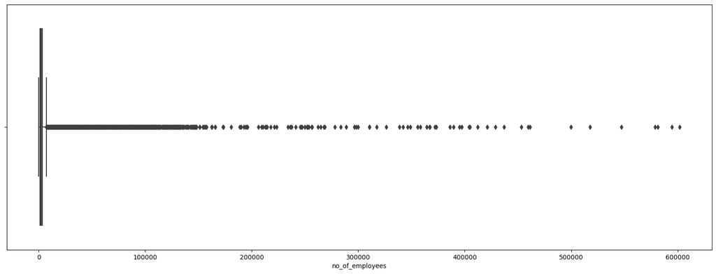

```python
# Creating a boxplot of number of employees
plt.figure(figsize=(20, 7))
sns.boxplot(data=df, x="no_of_employees")
plt.show()
```

- There seems to be staggered outliers beyond 150000 employees

```python
# Checking number of entries where there are more than 150000 employees
print(df[df["no_of_employees"] > 150000].shape[0])
```

```
90
```

- As the number of data entries compared to the total entries is not too statistically significant, we can remove these entries from our analysis to minimize outliers

```python
# Removing entries with employees greater than 150000 and checking the statistical summary
df = df[df["no_of_employees"] < 150000]
df.describe()
```

|  | no_of_employees | yr_of_estab | prevailing_wage |
| --- | --- | --- | --- |
| count | 25357.000000 | 25357.000000 | 25357.000000 |
| mean | 4645.782585 | 1979.420081 | 74500.796992 |
| std | 13411.540417 | 42.378159 | 52849.375252 |
| min | 12.000000 | 1800.000000 | 2.136700 |
| 25% | 1022.000000 | 1976.000000 | 34075.650000 |
| 50% | 2103.000000 | 1997.000000 | 70337.130000 |
| 75% | 3486.000000 | 2005.000000 | 107772.420000 |
| max | 147945.000000 | 2016.000000 | 319210.270000 |

- The standard deviation in the number of employees has decreased significantly without disturbing the other paramters

```python
df.info()
```

```
<class 'pandas.core.frame.DataFrame'>
Int64Index: 25357 entries, 0 to 25479
Data columns (total 12 columns):
 #   Column                 Non-Null Count  Dtype
---  ------                 --------------  -----
 0   case_id                25357 non-null  object
 1   continent              25357 non-null  object
 2   education_of_employee  25357 non-null  object
 3   has_job_experience     25357 non-null  object
 4   requires_job_training  25357 non-null  object
 5   no_of_employees        25357 non-null  int64
 6   yr_of_estab            25357 non-null  int64
 7   region_of_employment   25357 non-null  object
 8   prevailing_wage        25357 non-null  float64
 9   unit_of_wage           25357 non-null  object
 10  full_time_position     25357 non-null  object
 11  case_status            25357 non-null  object
dtypes: float64(1), int64(2), object(9)
memory usage: 2.5+ MB
```

```python
# Creating a Duplicate dataframe for modelling purposes and Dropping Case_ID Column
df_model = df
df_model = df_model.drop(["case_id"], axis=1)


# Creating Dummy Variables
df_model = pd.get_dummies(df_model, columns=["continent"], drop_first=True)
df_model = pd.get_dummies(df_model, columns=["education_of_employee"], drop_first=True)
df_model = pd.get_dummies(df_model, columns=["has_job_experience"], drop_first=True)
df_model = pd.get_dummies(df_model, columns=["requires_job_training"], drop_first=True)
df_model = pd.get_dummies(df_model, columns=["unit_of_wage"], drop_first=True)
df_model = pd.get_dummies(df_model, columns=["region_of_employment"], drop_first=True)
df_model = pd.get_dummies(df_model, columns=["full_time_position"], drop_first=True)
df_model
```

|  | no_of_employees | yr_of_estab | prevailing_wage | case_status | continent_Asia | continent_Europe | continent_North America | continent_Oceania | continent_South America | education_of_employee_Doctorate | ... | has_job_experience_Y | requires_job_training_Y | unit_of_wage_Month | unit_of_wage_Week | unit_of_wage_Year | region_of_employment_Midwest | region_of_employment_Northeast | region_of_employment_South | region_of_employment_West | full_time_position_Y |
| --- | --- | --- | --- | --- | --- | --- | --- | --- | --- | --- | --- | --- | --- | --- | --- | --- | --- | --- | --- | --- | --- |
| 0 | 14513 | 2007 | 592.2029 | Denied | 1 | 0 | 0 | 0 | 0 | 0 | ... | 0 | 0 | 0 | 0 | 0 | 0 | 0 | 0 | 1 | 1 |
| 1 | 2412 | 2002 | 83425.6500 | Certified | 1 | 0 | 0 | 0 | 0 | 0 | ... | 1 | 0 | 0 | 0 | 1 | 0 | 1 | 0 | 0 | 1 |
| 2 | 44444 | 2008 | 122996.8600 | Denied | 1 | 0 | 0 | 0 | 0 | 0 | ... | 0 | 1 | 0 | 0 | 1 | 0 | 0 | 0 | 1 | 1 |
| 3 | 98 | 1897 | 83434.0300 | Denied | 1 | 0 | 0 | 0 | 0 | 0 | ... | 0 | 0 | 0 | 0 | 1 | 0 | 0 | 0 | 1 | 1 |
| 4 | 1082 | 2005 | 149907.3900 | Certified | 0 | 0 | 0 | 0 | 0 | 0 | ... | 1 | 0 | 0 | 0 | 1 | 0 | 0 | 1 | 0 | 1 |
| ... | ... | ... | ... | ... | ... | ... | ... | ... | ... | ... | ... | ... | ... | ... | ... | ... | ... | ... | ... | ... | ... |
| 25475 | 2601 | 2008 | 77092.5700 | Certified | 1 | 0 | 0 | 0 | 0 | 0 | ... | 1 | 1 | 0 | 0 | 1 | 0 | 0 | 1 | 0 | 1 |
| 25476 | 3274 | 2006 | 279174.7900 | Certified | 1 | 0 | 0 | 0 | 0 | 0 | ... | 1 | 0 | 0 | 0 | 1 | 0 | 1 | 0 | 0 | 1 |
| 25477 | 1121 | 1910 | 146298.8500 | Certified | 1 | 0 | 0 | 0 | 0 | 0 | ... | 1 | 0 | 0 | 0 | 1 | 0 | 0 | 1 | 0 | 0 |
| 25478 | 1918 | 1887 | 86154.7700 | Certified | 1 | 0 | 0 | 0 | 0 | 0 | ... | 1 | 1 | 0 | 0 | 1 | 0 | 0 | 0 | 1 | 1 |
| 25479 | 3195 | 1960 | 70876.9100 | Certified | 1 | 0 | 0 | 0 | 0 | 0 | ... | 1 | 0 | 0 | 0 | 1 | 1 | 0 | 0 | 0 | 1 |

25357 rows × 22 columns

## EDA

- It is a good idea to explore the data once again after manipulating it.

```python
# Checking if the dummy variables were created properly
df_model.info()
```

```
<class 'pandas.core.frame.DataFrame'>
Int64Index: 25357 entries, 0 to 25479
Data columns (total 22 columns):
 #   Column                             Non-Null Count  Dtype
---  ------                             --------------  -----
 0   no_of_employees                    25357 non-null  int64
 1   yr_of_estab                        25357 non-null  int64
 2   prevailing_wage                    25357 non-null  float64
 3   case_status                        25357 non-null  object
 4   continent_Asia                     25357 non-null  uint8
 5   continent_Europe                   25357 non-null  uint8
 6   continent_North America            25357 non-null  uint8
 7   continent_Oceania                  25357 non-null  uint8
 8   continent_South America            25357 non-null  uint8
 9   education_of_employee_Doctorate    25357 non-null  uint8
 10  education_of_employee_High School  25357 non-null  uint8
 11  education_of_employee_Master's     25357 non-null  uint8
 12  has_job_experience_Y               25357 non-null  uint8
 13  requires_job_training_Y            25357 non-null  uint8
 14  unit_of_wage_Month                 25357 non-null  uint8
 15  unit_of_wage_Week                  25357 non-null  uint8
 16  unit_of_wage_Year                  25357 non-null  uint8
 17  region_of_employment_Midwest       25357 non-null  uint8
 18  region_of_employment_Northeast     25357 non-null  uint8
 19  region_of_employment_South         25357 non-null  uint8
 20  region_of_employment_West          25357 non-null  uint8
 21  full_time_position_Y               25357 non-null  uint8
dtypes: float64(1), int64(2), object(1), uint8(18)
memory usage: 1.4+ MB
```

```python
# Checking total number of columns and if all dummy variables contain only 2 unique values each
print(df_model.shape[1])
df_model.nunique()
```

```
22
```

```
no_of_employees                       7010
yr_of_estab                            199
prevailing_wage                      25331
case_status                              2
continent_Asia                           2
continent_Europe                         2
continent_North America                  2
continent_Oceania                        2
continent_South America                  2
education_of_employee_Doctorate          2
education_of_employee_High School        2
education_of_employee_Master's           2
has_job_experience_Y                     2
requires_job_training_Y                  2
unit_of_wage_Month                       2
unit_of_wage_Week                        2
unit_of_wage_Year                        2
region_of_employment_Midwest             2
region_of_employment_Northeast           2
region_of_employment_South               2
region_of_employment_West                2
full_time_position_Y                     2
dtype: int64
```

```python
# Making a duplicate dataset and replacing strings with binary values to show direct correlation trends in heatmap
df_hm = df_model.replace("Denied", 0)
df_hm = df_hm.replace("Certified", 1)

df_hm
```

|  | no_of_employees | yr_of_estab | prevailing_wage | case_status | continent_Asia | continent_Europe | continent_North America | continent_Oceania | continent_South America | education_of_employee_Doctorate | ... | has_job_experience_Y | requires_job_training_Y | unit_of_wage_Month | unit_of_wage_Week | unit_of_wage_Year | region_of_employment_Midwest | region_of_employment_Northeast | region_of_employment_South | region_of_employment_West | full_time_position_Y |
| --- | --- | --- | --- | --- | --- | --- | --- | --- | --- | --- | --- | --- | --- | --- | --- | --- | --- | --- | --- | --- | --- |
| 0 | 14513 | 2007 | 592.2029 | 0 | 1 | 0 | 0 | 0 | 0 | 0 | ... | 0 | 0 | 0 | 0 | 0 | 0 | 0 | 0 | 1 | 1 |
| 1 | 2412 | 2002 | 83425.6500 | 1 | 1 | 0 | 0 | 0 | 0 | 0 | ... | 1 | 0 | 0 | 0 | 1 | 0 | 1 | 0 | 0 | 1 |
| 2 | 44444 | 2008 | 122996.8600 | 0 | 1 | 0 | 0 | 0 | 0 | 0 | ... | 0 | 1 | 0 | 0 | 1 | 0 | 0 | 0 | 1 | 1 |
| 3 | 98 | 1897 | 83434.0300 | 0 | 1 | 0 | 0 | 0 | 0 | 0 | ... | 0 | 0 | 0 | 0 | 1 | 0 | 0 | 0 | 1 | 1 |
| 4 | 1082 | 2005 | 149907.3900 | 1 | 0 | 0 | 0 | 0 | 0 | 0 | ... | 1 | 0 | 0 | 0 | 1 | 0 | 0 | 1 | 0 | 1 |
| ... | ... | ... | ... | ... | ... | ... | ... | ... | ... | ... | ... | ... | ... | ... | ... | ... | ... | ... | ... | ... | ... |
| 25475 | 2601 | 2008 | 77092.5700 | 1 | 1 | 0 | 0 | 0 | 0 | 0 | ... | 1 | 1 | 0 | 0 | 1 | 0 | 0 | 1 | 0 | 1 |
| 25476 | 3274 | 2006 | 279174.7900 | 1 | 1 | 0 | 0 | 0 | 0 | 0 | ... | 1 | 0 | 0 | 0 | 1 | 0 | 1 | 0 | 0 | 1 |
| 25477 | 1121 | 1910 | 146298.8500 | 1 | 1 | 0 | 0 | 0 | 0 | 0 | ... | 1 | 0 | 0 | 0 | 1 | 0 | 0 | 1 | 0 | 0 |
| 25478 | 1918 | 1887 | 86154.7700 | 1 | 1 | 0 | 0 | 0 | 0 | 0 | ... | 1 | 1 | 0 | 0 | 1 | 0 | 0 | 0 | 1 | 1 |
| 25479 | 3195 | 1960 | 70876.9100 | 1 | 1 | 0 | 0 | 0 | 0 | 0 | ... | 1 | 0 | 0 | 0 | 1 | 1 | 0 | 0 | 0 | 1 |

25357 rows × 22 columns

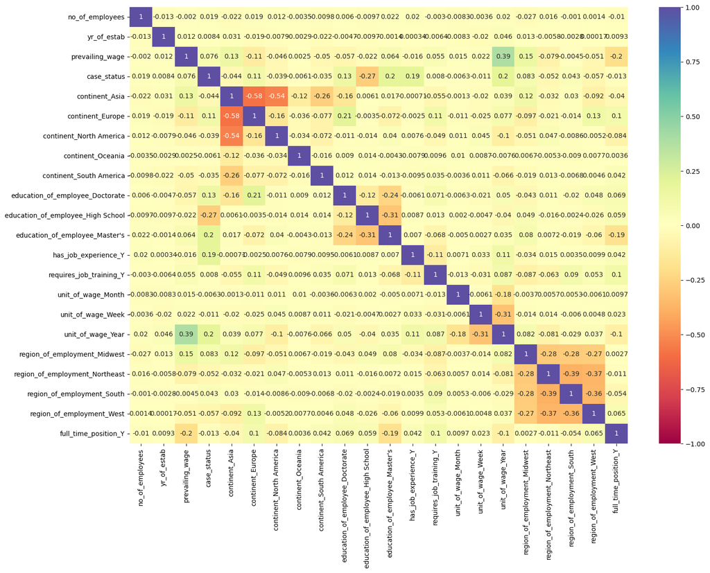

```python
# Creating a Heatmap
plt.figure(figsize=(17, 12))
sns.heatmap(df_hm.corr(numeric_only=True), annot=True, cmap="Spectral", vmin=-1, vmax=1)
plt.show()
```

- From the heatmap we can see a decent correlation with the education of the employee [negative for high school candidates, positive for the rest] as well as the unit of wage payment (a good positive correlation for employees paid yearly instead of weekly,hourly or monthly)

### Section Summary

- Verified the dummy variables were created properly and that the total number of columns matched with the number of dummy variables
- Created a heatmap for a rough correlation analysis on what variables had the strongest influence on case status

## Building bagging models

```python
df_model.head()
```

|  | no_of_employees | yr_of_estab | prevailing_wage | case_status | continent_Asia | continent_Europe | continent_North America | continent_Oceania | continent_South America | education_of_employee_Doctorate | ... | has_job_experience_Y | requires_job_training_Y | unit_of_wage_Month | unit_of_wage_Week | unit_of_wage_Year | region_of_employment_Midwest | region_of_employment_Northeast | region_of_employment_South | region_of_employment_West | full_time_position_Y |
| --- | --- | --- | --- | --- | --- | --- | --- | --- | --- | --- | --- | --- | --- | --- | --- | --- | --- | --- | --- | --- | --- |
| 0 | 14513 | 2007 | 592.2029 | Denied | 1 | 0 | 0 | 0 | 0 | 0 | ... | 0 | 0 | 0 | 0 | 0 | 0 | 0 | 0 | 1 | 1 |
| 1 | 2412 | 2002 | 83425.6500 | Certified | 1 | 0 | 0 | 0 | 0 | 0 | ... | 1 | 0 | 0 | 0 | 1 | 0 | 1 | 0 | 0 | 1 |
| 2 | 44444 | 2008 | 122996.8600 | Denied | 1 | 0 | 0 | 0 | 0 | 0 | ... | 0 | 1 | 0 | 0 | 1 | 0 | 0 | 0 | 1 | 1 |
| 3 | 98 | 1897 | 83434.0300 | Denied | 1 | 0 | 0 | 0 | 0 | 0 | ... | 0 | 0 | 0 | 0 | 1 | 0 | 0 | 0 | 1 | 1 |
| 4 | 1082 | 2005 | 149907.3900 | Certified | 0 | 0 | 0 | 0 | 0 | 0 | ... | 1 | 0 | 0 | 0 | 1 | 0 | 0 | 1 | 0 | 1 |

5 rows × 22 columns

```python
df_model = df_model.replace("Denied", 0)
df_model = df_model.replace("Certified", 1)
```

### Splitting the Data into train and test and creating model functions

```python
# Splitting Data into training and testing (70% train 30% test)
X = df_model.drop("case_status", axis=1)
y = df_model.pop("case_status")

X_train, X_test, y_train, y_test = train_test_split(
    X, y, test_size=0.30, random_state=1, stratify=y
)
```

```python
## Function to create confusion matrix
def make_confusion_matrix(model, y_actual, labels=[1, 0]):
    """
    model : classifier to predict values of X
    y_actual : ground truth

    """
    y_predict = model.predict(X_test)
    cm = metrics.confusion_matrix(y_actual, y_predict, labels=[0, 1])
    df_cm = pd.DataFrame(
        cm,
        index=[i for i in ["Actual - No", "Actual - Yes"]],
        columns=[i for i in ["Predicted - No", "Predicted - Yes"]],
    )
    group_counts = ["{0:0.0f}".format(value) for value in cm.flatten()]
    group_percentages = ["{0:.2%}".format(value) for value in cm.flatten() / np.sum(cm)]
    labels = [f"{v1}\n{v2}" for v1, v2 in zip(group_counts, group_percentages)]
    labels = np.asarray(labels).reshape(2, 2)
    plt.figure(figsize=(10, 7))
    sns.heatmap(df_cm, annot=labels, fmt="")
    plt.ylabel("True label")
    plt.xlabel("Predicted label")
```

```python
##  Function to calculate different metric scores of the model - Accuracy, Recall and Precision
def get_metrics_score(model, flag=True):
    """
    model : classifier to predict values of X

    """
    # defining an empty list to store train and test results
    score_list = []

    # Predicting on train and tests
    pred_train = model.predict(X_train)
    pred_test = model.predict(X_test)

    # Accuracy of the model
    train_acc = model.score(X_train, y_train)
    test_acc = model.score(X_test, y_test)

    # Recall of the model
    train_recall = metrics.recall_score(y_train, pred_train)
    test_recall = metrics.recall_score(y_test, pred_test)

    # Precision of the model
    train_precision = metrics.precision_score(y_train, pred_train)
    test_precision = metrics.precision_score(y_test, pred_test)

    score_list.extend(
        (
            train_acc,
            test_acc,
            train_recall,
            test_recall,
            train_precision,
            test_precision,
        )
    )

    # If the flag is set to True then only the following print statements will be dispayed. The default value is set to True.
    if flag == True:
        print("Accuracy on training set : ", model.score(X_train, y_train))
        print("Accuracy on test set : ", model.score(X_test, y_test))
        print("Recall on training set : ", metrics.recall_score(y_train, pred_train))
        print("Recall on test set : ", metrics.recall_score(y_test, pred_test))
        print(
            "Precision on training set : ", metrics.precision_score(y_train, pred_train)
        )
        print("Precision on test set : ", metrics.precision_score(y_test, pred_test))

    return score_list  # returning the list with train and test scores
```

### [1] Creating a Bagging Classifier

```python
# Creating a Base estimator for bagging classifier
bagging_estimator = BaggingClassifier(random_state=1)
bagging_estimator.fit(X_train, y_train)
```

```
BaggingClassifier(random_state=1)
```

```python
# Using above defined function to get accuracy, recall and precision on train and test set
bagging_estimator_score = get_metrics_score(bagging_estimator)
```

```
Accuracy on training set :  0.985351287396473
Accuracy on test set :  0.7066246056782335
Recall on training set :  0.9874378214315825
Recall on test set :  0.7842250196695515
Precision on training set :  0.9906115199188024
Precision on test set :  0.7784068723155018
```

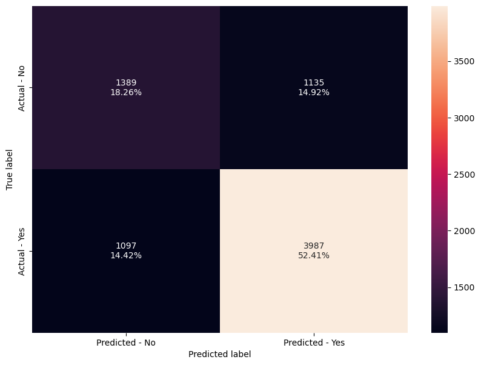

```python
# Creating a confusion matrix
make_confusion_matrix(bagging_estimator, y_test)
```

- The model has excellent accuracy and recall on train data but significantly lower metrics on the test data which indicates overfitting

### [2] Creating a Random Forest Classifier

```python
# Train the random forest classifier
rf_estimator = RandomForestClassifier(random_state=1)
rf_estimator.fit(X_train, y_train)
```

```
RandomForestClassifier(random_state=1)
```

```python
# Using above defined function to get accuracy, recall and precision on train and test set
rf_estimator_score = get_metrics_score(rf_estimator)
```

```
Accuracy on training set :  1.0
Accuracy on test set :  0.7283123028391167
Recall on training set :  1.0
Recall on test set :  0.8440204563335956
Precision on training set :  1.0
Precision on test set :  0.7710691823899372
```

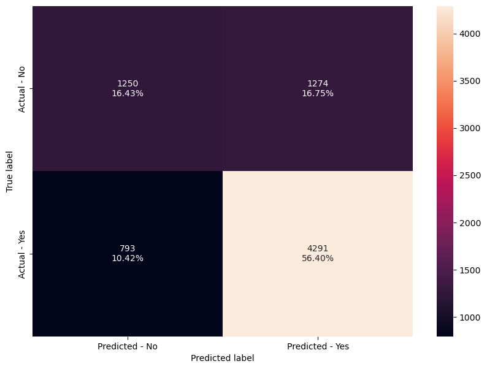

```python
# Creating a Confusion Matrix
make_confusion_matrix(rf_estimator, y_test)
```

### [3] Creating a decision tree classifier

```python
# Creating a Decision Tree Classifier from the Training Data
dTree = DecisionTreeClassifier(criterion="gini", random_state=1)
dTree.fit(X_train, y_train)
```

```
DecisionTreeClassifier(random_state=1)
```

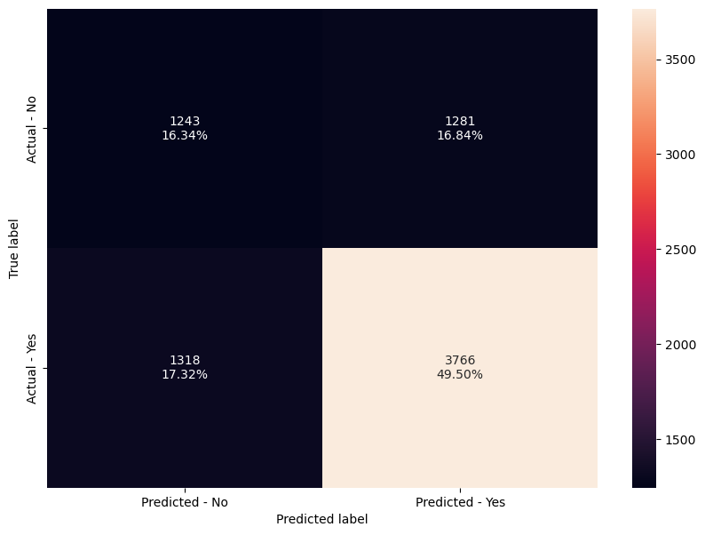

```python
# Creating a Confusion Matrix
make_confusion_matrix(dTree, y_test)
```

```python
dTree_score = get_metrics_score(dTree)
```

```
Accuracy on training set :  1.0
Accuracy on test set :  0.6583859095688749
Recall on training set :  1.0
Recall on test set :  0.7407553107789142
Precision on training set :  1.0
Precision on test set :  0.7461858529819695
```

- This model has the lowest test data metrics compared to the above 2 models and still has a 100% accuracy on the training data due to the tree being unpruned and overfitting the training data

## Will tuning the hyperparameters improve the model performance?

### Utilizing Hyperparameter tuning and other model improvement methods

### [1] Hyperparameter Bagging Classifier

```python
# Using Bagging Classifier
bagging_estimator_tuned = BaggingClassifier(random_state=1)

# Grid of parameters
parameters = {
    "max_samples": [0.8, 0.9, 1],
    "max_features": [0.7, 0.8, 0.9],
    "n_estimators": [30, 50, 70],
}

# Creating a scorer to measure recall metrics
acc_scorer = metrics.make_scorer(metrics.recall_score)

# To run the grid search
grid_obj = GridSearchCV(bagging_estimator_tuned, parameters, scoring=acc_scorer, cv=5)
grid_obj = grid_obj.fit(X_train, y_train)

# Set the classifier to the best combination of parameters
bagging_estimator_tuned = grid_obj.best_estimator_

# Fit the best algorithm to the data.
bagging_estimator_tuned.fit(X_train, y_train)
```

```
BaggingClassifier(max_features=0.7, max_samples=1, n_estimators=30,
                  random_state=1)
```

```python
# Using above defined function to get accuracy, recall and precision on train and test set
bagging_estimator_tuned_score = get_metrics_score(bagging_estimator_tuned)
```

```
Accuracy on training set :  0.6682630007324356
Accuracy on test set :  0.6682439537329127
Recall on training set :  1.0
Recall on test set :  1.0
Precision on training set :  0.6682630007324356
Precision on test set :  0.6682439537329127
```

```python
# Creating a Confusion Matrix
make_confusion_matrix(bagging_estimator_tuned, y_test)
```

[output not shown]

### [2] Logistic Regression Bagging Classifier

```python
# Creating a Logistic Regression Bagging Classifier using the Training Data
bagging_lr = BaggingClassifier(
    estimator=LogisticRegression(solver="liblinear", random_state=1, max_iter=1000),
    random_state=1,
)
bagging_lr.fit(X_train, y_train)
```

```
BaggingClassifier(estimator=LogisticRegression(max_iter=1000, random_state=1,
                                               solver='liblinear'),
                  random_state=1)
```

```python
# Using above defined function to get accuracy, recall and precision on train and test set
bagging_lr_score = get_metrics_score(bagging_lr)
```

```
Accuracy on training set :  0.6682630007324356
Accuracy on test set :  0.6682439537329127
Recall on training set :  1.0
Recall on test set :  1.0
Precision on training set :  0.6682630007324356
Precision on test set :  0.6682439537329127
```

```python
# Creating Confusion Matrix
make_confusion_matrix(bagging_lr, y_test)
```

[output not shown]

- Even with logistic regression the model only predicts yes
- Out of the different bagging variations, it is best to stick to the original bagging model

### [3] Random Forest Hyperparameter Tuning

```python
# Using Random Forest Classifier
rf_estimator_tuned = RandomForestClassifier(random_state=1)

# Creating a grid of hyperparameters
parameters = {
    "n_estimators": [50, 110, 25],
    "min_samples_leaf": np.arange(1, 4),
    "max_features": [np.arange(0.3, 0.6, 0.1), "sqrt"],
    "max_samples": np.arange(0.4, 0.7, 0.1),
}

# Creating a scorer to measure recall metrics
acc_scorer = metrics.make_scorer(metrics.recall_score)

# Running grid search
grid_obj = GridSearchCV(rf_estimator_tuned, parameters, scoring=acc_scorer, cv=5)
grid_obj = grid_obj.fit(X_train, y_train)

# Set the classifier to the best combination of parameters
rf_estimator_tuned = grid_obj.best_estimator_

# Fit the best algorithm to the data.
rf_estimator_tuned.fit(X_train, y_train)
```

```
RandomForestClassifier(max_samples=0.4, min_samples_leaf=3, n_estimators=50,
                       random_state=1)
```

```python
# Using above defined function to get accuracy, recall and precision on train and test set
rf_estimator_tuned_score = get_metrics_score(rf_estimator_tuned)
```

```
Accuracy on training set :  0.7927207166600935
Accuracy on test set :  0.7493427970557308
Recall on training set :  0.9070904645476773
Recall on test set :  0.8766719118804092
Precision on training set :  0.8067636472705458
Precision on test set :  0.7768868746731742
```

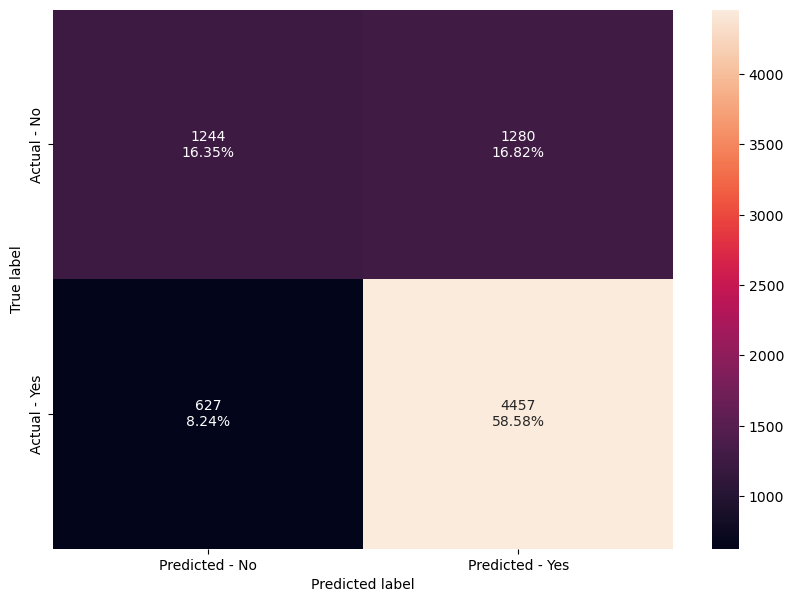

```python
# Creating a Confusion Matrix
make_confusion_matrix(rf_estimator_tuned, y_test)
```

- From tuning the Random Forest Classifier, our test recall has improved and the training and test data metrics are much similar to one another, indicating that we've reduced overfitting through hyperparameter tuning

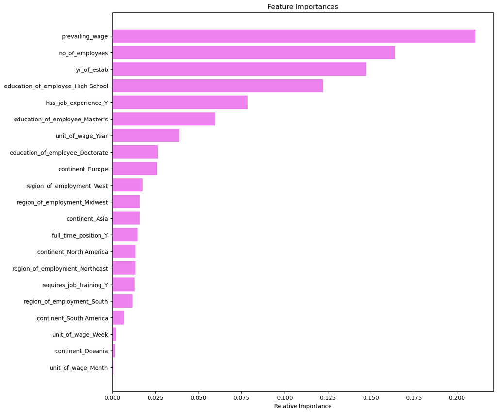

```python
# Plotting a bar chart showing the features prioritized by the model in predicting outcomes
importances = rf_estimator_tuned.feature_importances_
indices = np.argsort(importances)
feature_names = list(X.columns)

plt.figure(figsize=(12, 12))
plt.title("Feature Importances")
plt.barh(range(len(indices)), importances[indices], color="violet", align="center")
plt.yticks(range(len(indices)), [feature_names[i] for i in indices])
plt.xlabel("Relative Importance")
plt.show()
```

- The tuned Random Forest model found that the 3 most important parameters were: 1) Their Prevailing Wage 2) The number of employees in the company 3) The year the company was established
- These are the main numerical variables in our dataset too, which indicates that the Random Forest Model primarily used numerical data rather than categorical data in making its predictions

### [4] Decision Tree Hyperparameter Tuning

```python
# Using Decision Tree Classifier
dt_estimator = DecisionTreeClassifier(random_state=1)

# Creating Grid of Hyperparameters
parameters = {
    "max_depth": np.arange(2, 6),
    "min_samples_leaf": [1, 4, 7],
    "max_leaf_nodes": [8, 10, 15],
    "min_impurity_decrease": [0.0001, 0.001],
}

# Creating a scorer to measure recall metrics
acc_scorer = metrics.make_scorer(metrics.recall_score)

# Running the grid search
grid_obj = GridSearchCV(dt_estimator, parameters, scoring=acc_scorer, cv=5)
grid_obj = grid_obj.fit(X_train, y_train)

# Set the classifier to the best combination of parameters
dt_estimator_tuned = grid_obj.best_estimator_

# Fit the best algorithm to the data.
dt_estimator_tuned.fit(X_train, y_train)
```

```
DecisionTreeClassifier(max_depth=3, max_leaf_nodes=8,
                       min_impurity_decrease=0.0001, random_state=1)
```

```python
# Using above defined function to get accuracy, recall and precision on train and test set
dt_estimator_tuned_score = get_metrics_score(dt_estimator_tuned)
```

```
Accuracy on training set :  0.7311961237252803
Accuracy on test set :  0.7309411146161935
Recall on training set :  0.9210016018885423
Recall on test set :  0.9232887490165225
Precision on training set :  0.7402087003659032
Precision on test set :  0.7390962053219965
```

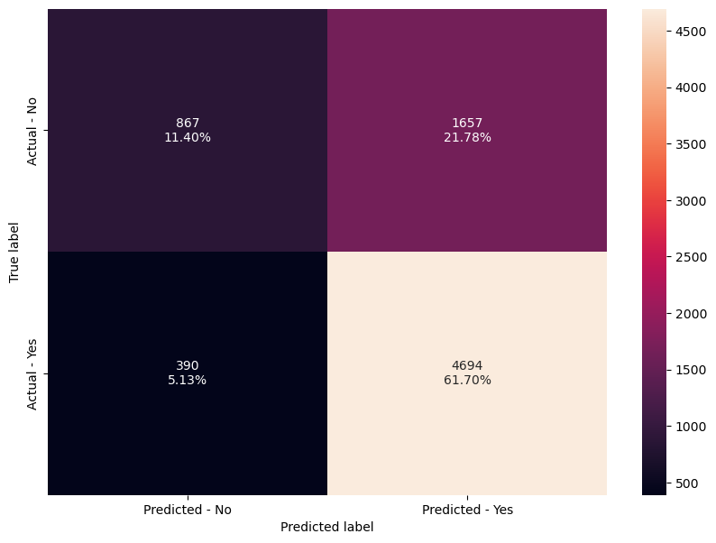

```python
make_confusion_matrix(dt_estimator_tuned, y_test)
```

- Test recall and accuracy of the Decision Tree Model have improved greatly and the metrics between test and training data are similar indicating that the model is no longer overfit

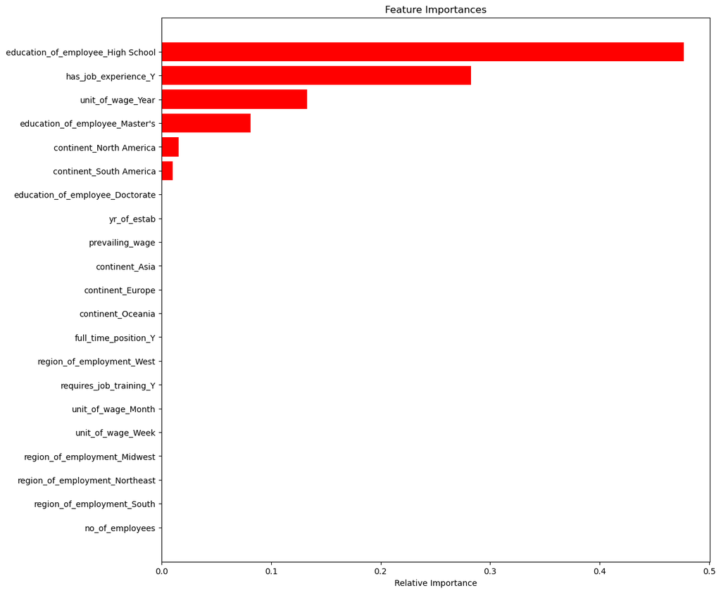

```python
importances = dt_estimator_tuned.feature_importances_
indices = np.argsort(importances)
feature_names = list(X.columns)

plt.figure(figsize=(12, 12))
plt.title("Feature Importances")
plt.barh(range(len(indices)), importances[indices], color="red", align="center")
plt.yticks(range(len(indices)), [feature_names[i] for i in indices])
plt.xlabel("Relative Importance")
plt.show()
```

- The Decision Tree model found that the 3 most important parameters were: 1) If the employee's highest level of education was in high school 2) If the employee had job experience 3) If the employee was paid an annual salary

### Summarizing Bagging, Random Forest and Decision Tree Models (w/ and w/o Tuning)

```python
# defining list of models
models = [
    bagging_estimator,
    bagging_estimator_tuned,
    bagging_lr,
    rf_estimator,
    rf_estimator_tuned,
    dTree,
    dt_estimator_tuned,
]

# defining empty lists to add train and test results
acc_train = []
acc_test = []
recall_train = []
recall_test = []
precision_train = []
precision_test = []

# looping through all the models to get the accuracy, precall and precision scores
for model in models:
    j = get_metrics_score(model, False)
    acc_train.append(np.round(j[0], 2))
    acc_test.append(np.round(j[1], 2))
    recall_train.append(np.round(j[2], 2))
    recall_test.append(np.round(j[3], 2))
    precision_train.append(np.round(j[4], 2))
    precision_test.append(np.round(j[5], 2))
```

```python
comparison_frame = pd.DataFrame(
    {
        "Model": [
            "Bagging classifier with default parameters",
            "Tuned Bagging Classifier",
            "Bagging classifier with base_estimator=LR",
            "Random Forest with deafult parameters",
            "Tuned Random Forest Classifier",
            "Decision Tree with default parameters",
            "Tuned Decision Tree",
        ],
        "Train_Accuracy": acc_train,
        "Test_Accuracy": acc_test,
        "Train_Recall": recall_train,
        "Test_Recall": recall_test,
        "Train_Precision": precision_train,
        "Test_Precision": precision_test,
    }
)
comparison_frame
```

|  | Model | Train_Accuracy | Test_Accuracy | Train_Recall | Test_Recall | Train_Precision | Test_Precision |
| --- | --- | --- | --- | --- | --- | --- | --- |
| 0 | Bagging classifier with default parameters | 0.99 | 0.71 | 0.99 | 0.78 | 0.99 | 0.78 |
| 1 | Tuned Bagging Classifier | 0.67 | 0.67 | 1.00 | 1.00 | 0.67 | 0.67 |
| 2 | Bagging classifier with base_estimator=LR | 0.67 | 0.67 | 1.00 | 1.00 | 0.67 | 0.67 |
| 3 | Random Forest with deafult parameters | 1.00 | 0.73 | 1.00 | 0.84 | 1.00 | 0.77 |
| 4 | Tuned Random Forest Classifier | 0.79 | 0.75 | 0.91 | 0.88 | 0.81 | 0.78 |
| 5 | Decision Tree with default parameters | 1.00 | 0.66 | 1.00 | 0.74 | 1.00 | 0.75 |
| 6 | Tuned Decision Tree | 0.73 | 0.73 | 0.92 | 0.92 | 0.74 | 0.74 |

### Section Summary

- We created 7 models, 3 Bagging Classifiers, 2 Random Forest Classifiers and 2 Decision Tree models
- Bagging models would either overfit the data or would predict all visa's as certified when tuned so none of the bagging models are recommended to implement for business predicitons
- While default Random Forest and Decision Tree classifiers tend to overfit the training data, upon tuning those models would provide good accuracy, precision and recall scores
- We will compare these two models once again with the boosting models and see which model(s) to finally decide upon

## Building Boosting Models

### [1] AdaBoost Classifier

```python
# Using the Adaptive Boost Classifier function on training data
ada = AdaBoostClassifier(random_state=1)
ada.fit(X_train, y_train)
```

```
AdaBoostClassifier(random_state=1)
```

```python
# Using above defined function to get accuracy, recall and precision on train and test set
ada_score = get_metrics_score(ada)
```

```
Accuracy on training set :  0.7349709842808045
Accuracy on test set :  0.7381703470031545
Recall on training set :  0.885422814265239
Recall on test set :  0.8898505114083399
Precision on training set :  0.7584314291904384
Precision on test set :  0.7595701813297515
```

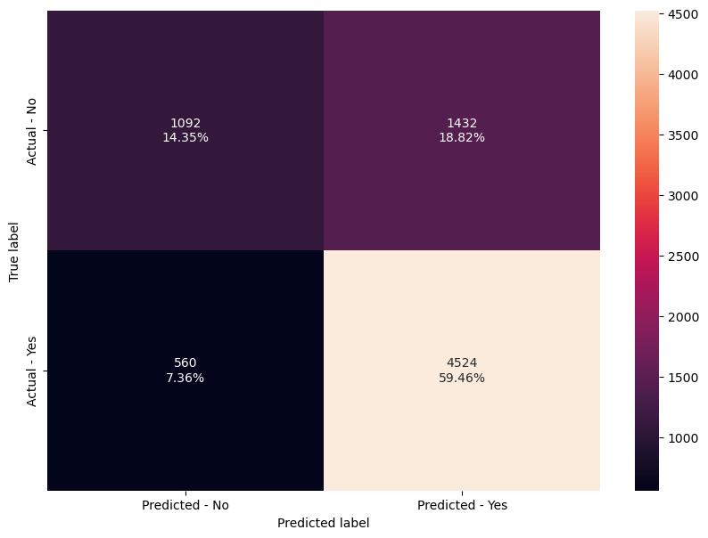

```python
# Creating a Confusion Matrix
make_confusion_matrix(ada, y_test)
```

- The recall on AdaBoost Classifier is quite good and there doesn't seem to be any indicators of overfitting
- The metrics on test data are surprisingly slightly higher than that of the training data

### [2] Gradient Boost Classifier

```python
# Using the GB Classifier function on training data
gbc = GradientBoostingClassifier(random_state=1)
gbc.fit(X_train, y_train)
```

```
GradientBoostingClassifier(random_state=1)
```

```python
# Using above defined function to get accuracy, recall and precision on train and test set
gbc_score = get_metrics_score(gbc)
```

```
Accuracy on training set :  0.7534508986421771
Accuracy on test set :  0.7555205047318612
Recall on training set :  0.8783407807098895
Recall on test set :  0.8829661683713611
Precision on training set :  0.78031608119242
Precision on test set :  0.7801529370872436
```

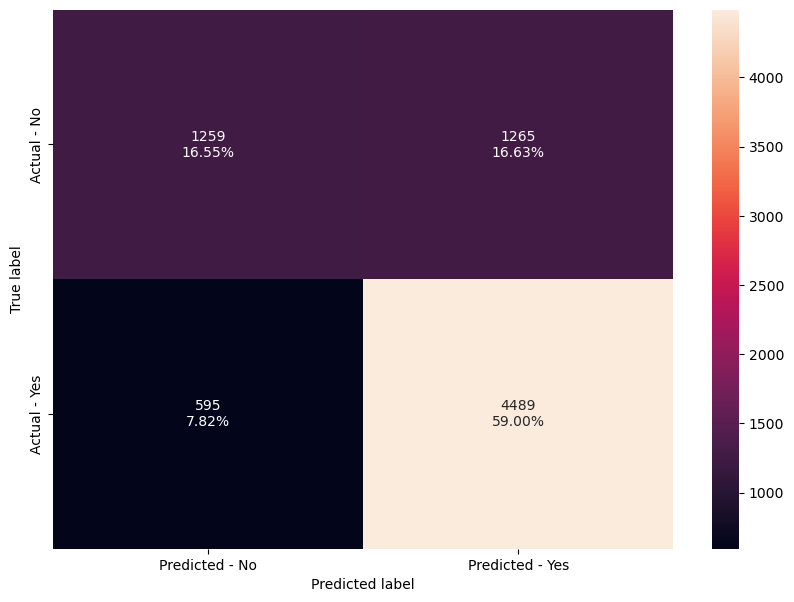

```python
# Creating a Confusion Matrix
make_confusion_matrix(gbc, y_test)
```

- Gradient Boost Classifier performance shows very similar metrics on training and test data as Adaptive Boosting with slightly higher precision on training and test data
- No Indication of overfitting in this model as well

### [3] XGBoost Classifier

```python
# Using the XGBoost Classifier function on training data
xgb = XGBClassifier(random_state=1, eval_metric="logloss")
xgb.fit(X_train, y_train)
```

```
XGBClassifier(base_score=None, booster=None, callbacks=None,
              colsample_bylevel=None, colsample_bynode=None,
              colsample_bytree=None, device=None, early_stopping_rounds=None,
              enable_categorical=False, eval_metric='logloss',
              feature_types=None, gamma=None, grow_policy=None,
              importance_type=None, interaction_constraints=None,
              learning_rate=None, max_bin=None, max_cat_threshold=None,
              max_cat_to_onehot=None, max_delta_step=None, max_depth=None,
              max_leaves=None, min_child_weight=None, missing=nan,
              monotone_constraints=None, multi_strategy=None, n_estimators=None,
              n_jobs=None, num_parallel_tree=None, random_state=1, ...)
```

```python
# Using above defined function to get accuracy, recall and precision on train and test set
xgb_score = get_metrics_score(xgb)
```

```
Accuracy on training set :  0.8407797622401262
Accuracy on test set :  0.7365930599369085
Recall on training set :  0.9317089621448444
Recall on test set :  0.8607395751376868
Precision on training set :  0.845718221473942
Precision on test set :  0.771509167842031
```

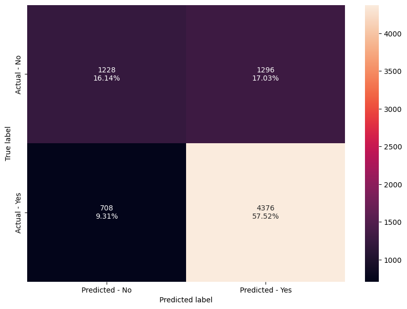

```python
# Creating a Confusion Matrix
make_confusion_matrix(xgb, y_test)
```

- While test mdata metrics are satisfactory, there is a decent margin between the training data metrics and test data metrics indicating an overfit model
- We will see if we can resolve this through tuning

## Will tuning the hyperparameters improve the model performance?

### [1] Hyperparameter tuned AdaBoosting

- As processing time was slow, each of the parameters were tuned individually to find the optimal value (n_estimators = 75 and learning_rate = 0.05)

```python
# Choose the type of classifier.
ada_tuned = AdaBoostClassifier(random_state=1)

# Grid of parameters to choose from
## add from article
parameters = {
    "n_estimators": [75],
    "learning_rate": [0.05],
    "base_estimator": [
        DecisionTreeClassifier(max_depth=2, random_state=1),
        DecisionTreeClassifier(max_depth=3, random_state=1),
    ],
}

# Type of scoring used to compare parameter combinations
acc_scorer = metrics.make_scorer(metrics.recall_score)

# Run the grid search
grid_obj = GridSearchCV(ada_tuned, parameters, scoring=acc_scorer, cv=5)
grid_obj = grid_obj.fit(X_train, y_train)

# Set the clf to the best combination of parameters
ada_tuned = grid_obj.best_estimator_

# Fit the best algorithm to the data.
ada_tuned.fit(X_train, y_train)
```

```
AdaBoostClassifier(base_estimator=DecisionTreeClassifier(max_depth=2,
                                                         random_state=1),
                   learning_rate=0.05, n_estimators=75, random_state=1)
```

```python
# Using above defined function to get accuracy, recall and precision on train and test set
ada_tuned_score = get_metrics_score(ada_tuned)
```

```
Accuracy on training set :  0.7295058876556426
Accuracy on test set :  0.7351472134595163
Recall on training set :  0.9083551133968468
Recall on test set :  0.9138473642800944
Precision on training set :  0.7436499171728327
Precision on test set :  0.7465852482725374
```

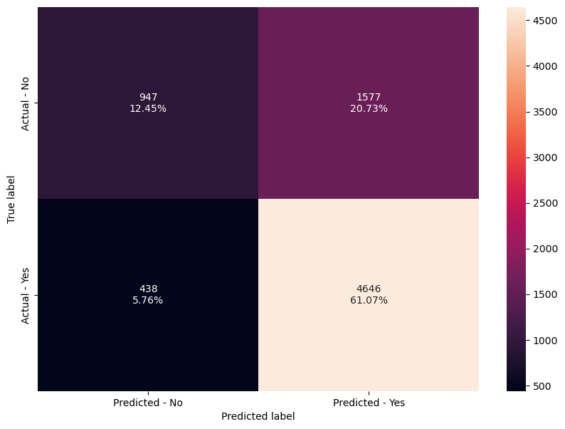

```python
# Creating a Confusion Matrix
make_confusion_matrix(abc_tuned, y_test)
```

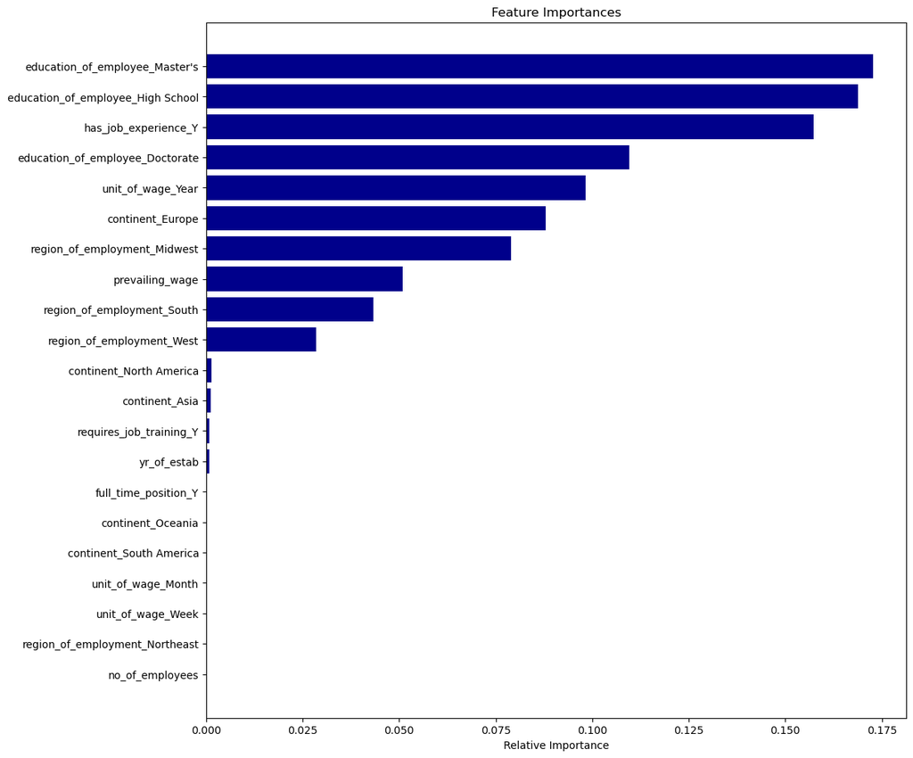

```python
# Plotting important features in predicting if the visa is accepted or not
importances = ada_tuned.feature_importances_
indices = np.argsort(importances)
feature_names = list(X.columns)

plt.figure(figsize=(12, 12))
plt.title("Feature Importances")
plt.barh(range(len(indices)), importances[indices], color="darkblue", align="center")
plt.yticks(range(len(indices)), [feature_names[i] for i in indices])
plt.xlabel("Relative Importance")
plt.show()
```

- The tuned AdaBoost model found that the most important parameters were: 1) If the employee's highest level of education was either in high school or if they completed their Masters 2) If the employee had job experience

### [2] Hyperparameter Tuned Gradient Boosting

```python
gbc_init = GradientBoostingClassifier(
    init=AdaBoostClassifier(random_state=1), random_state=1
)
gbc_init.fit(X_train, y_train)
```

```
GradientBoostingClassifier(init=AdaBoostClassifier(random_state=1),
                           random_state=1)
```

```python
# Using above defined function to get accuracy, recall and precision on train and test set
gbc_init_score = get_metrics_score(gbc_init)
```

```
Accuracy on training set :  0.7535635810468195
Accuracy on test set :  0.7555205047318612
Recall on training set :  0.8782564707866116
Recall on test set :  0.8835562549173879
Precision on training set :  0.7804750131115606
Precision on test set :  0.7798611111111111
```

- Metrics are similar to default parameter gradient boosting so we will stick to that
- As processing time was slow, each of the parameters were tuned individually to find the optimal value (n_estimators = 50, learning_rate = 0.01 and subsample = 0.7)

```python
# Using the Gradient Boost Classifier
gbc_tuned = GradientBoostingClassifier(
    init=AdaBoostClassifier(random_state=1), random_state=1
)

# Grid of parameters to choose from
parameters = {
    "init": [
        AdaBoostClassifier(random_state=1),
        DecisionTreeClassifier(random_state=1),
    ],
    "n_estimators": [50],
    "learning_rate": [0.01],
    "subsample": [0.7],
    "max_features": [0.5, 0.7, 1],
}

# Type of scoring used to compare parameter combinations
acc_scorer = metrics.make_scorer(metrics.recall_score)

# Run the grid search
grid_obj = GridSearchCV(gbc_tuned, parameters, scoring=acc_scorer, cv=5)
grid_obj = grid_obj.fit(X_train, y_train)

# Set the classifier to the best combination of parameters
gbc_tuned = grid_obj.best_estimator_

# Fit the best algorithm to the data.
gbc_tuned.fit(X_train, y_train)
```

```
GradientBoostingClassifier(init=AdaBoostClassifier(random_state=1),
                           learning_rate=0.01, max_features=1, n_estimators=50,
                           random_state=1, subsample=0.7)
```

```python
# Using above defined function to get accuracy, recall and precision on train and test set
gbc_tuned_score = get_metrics_score(gbc_tuned)
```

```
Accuracy on training set :  0.6755873570341991
Accuracy on test set :  0.6762618296529969
Recall on training set :  0.9949414046033218
Recall on test set :  0.9939024390243902
Precision on training set :  0.6743813932224698
Precision on test set :  0.6750835003340013
```

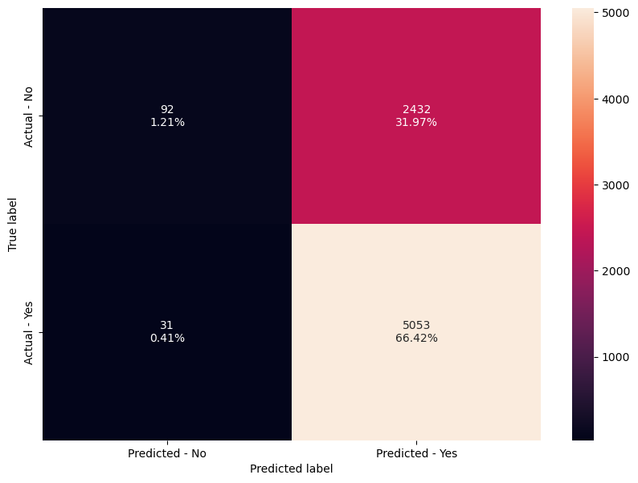

```python
# Creating a Confusion Matrix
make_confusion_matrix(gbc_tuned, y_test)
```

- In the tuned gradient boost model, the predictor was inclined to predict that all entires would be Certified which was a similar problem to our tuned Bagging models, recall is very high but accuracy is low

### [3] XGBoost Hyperparameter Tuning

```python
# XGBoost Classifier
xgb_tuned = XGBClassifier(random_state=1, eval_metric="logloss")

# Grid of parameters to choose from
parameters = {
    "n_estimators": np.arange(50, 110, 25),
    "scale_pos_weight": [1, 2, 5],
    "learning_rate": [0.01, 0.1, 0.05],
    "gamma": [1, 3],
    "subsample": [0.7, 0.9],
}

# Type of scoring used to compare parameter combinations
acc_scorer = metrics.make_scorer(metrics.recall_score)

# Run the grid search
grid_obj = GridSearchCV(xgb_tuned, parameters, scoring=acc_scorer, cv=5)
grid_obj = grid_obj.fit(X_train, y_train)

# Set the classifier to the best combination of parameters
xgb_tuned = grid_obj.best_estimator_

# Fit the best algorithm to the data.
xgb_tuned.fit(X_train, y_train)
```

```
XGBClassifier(base_score=None, booster=None, callbacks=None,
              colsample_bylevel=None, colsample_bynode=None,
              colsample_bytree=None, device=None, early_stopping_rounds=None,
              enable_categorical=False, eval_metric='logloss',
              feature_types=None, gamma=1, grow_policy=None,
              importance_type=None, interaction_constraints=None,
              learning_rate=0.01, max_bin=None, max_cat_threshold=None,
              max_cat_to_onehot=None, max_delta_step=None, max_depth=None,
              max_leaves=None, min_child_weight=None, missing=nan,
              monotone_constraints=None, multi_strategy=None, n_estimators=50,
              n_jobs=None, num_parallel_tree=None, random_state=1, ...)
```

```python
# Using above defined function to get accuracy, recall and precision on train and test set
xgb_tuned_score = get_metrics_score(xgb_tuned)
```

```
Accuracy on training set :  0.6682630007324356
Accuracy on test set :  0.6682439537329127
Recall on training set :  1.0
Recall on test set :  1.0
Precision on training set :  0.6682630007324356
Precision on test set :  0.6682439537329127
```

```python
make_confusion_matrix(xgb_tuned, y_test)
```

[output not shown]

- Similar to the tuned Bagging and Gradient Boost models, the XGBoost Classifier predicted all positive outcomes, leading to maximum recall but low accuracy and an impractical model

## Model Performance Comparison and Conclusions

### Refer to Section Summary of Bagging for all Bagging model comparisons, as Tuned Decision Tree and Tuned Random Forest were identified to be the most practical models from that section, we are inputting them and comparing those with our boosting models to find which model(s) to utilize

```python
# defining list of models
models = [
    ada,
    ada_tuned,
    gbc,
    gbc_tuned,
    xgb,
    xgb_tuned,
    dt_estimator_tuned,
    rf_estimator_tuned,
]

# defining empty lists to add train and test results
acc_train = []
acc_test = []
recall_train = []
recall_test = []
precision_train = []
precision_test = []

# looping through all the models to get the accuracy, precall and precision scores
for model in models:
    j = get_metrics_score(model, False)
    acc_train.append(np.round(j[0], 2))
    acc_test.append(np.round(j[1], 2))
    recall_train.append(np.round(j[2], 2))
    recall_test.append(np.round(j[3], 2))
    precision_train.append(np.round(j[4], 2))
    precision_test.append(np.round(j[5], 2))
```

```python
# Creating a Dataframe to compare the models
comparison_frame2 = pd.DataFrame({'Model':['AdaBoost with default paramters','AdaBoost Tuned',
                                          'Gradient Boosting with default parameters','Gradient Boosting Tuned with init=AdaBoost',
                                          'XGBoost with default parameters','XGBoost Tuned', 'Decision Tree Tuned', 'Random Forest Tuned'],
                                          'Train_Accuracy': acc_train,'Test_Accuracy': acc_test,
                                          'Train_Recall':recall_train,'Test_Recall':recall_test,
                                          'Train_Precision':precision_train,'Test_Precision':precision_test})
comparison_frame2
```

|  | Model | Train_Accuracy | Test_Accuracy | Train_Recall | Test_Recall | Train_Precision | Test_Precision |
| --- | --- | --- | --- | --- | --- | --- | --- |
| 0 | AdaBoost with default paramters | 0.73 | 0.74 | 0.89 | 0.89 | 0.76 | 0.76 |
| 1 | AdaBoost Tuned | 0.73 | 0.74 | 0.91 | 0.91 | 0.74 | 0.75 |
| 2 | Gradient Boosting with default parameters | 0.75 | 0.76 | 0.88 | 0.88 | 0.78 | 0.78 |
| 3 | Gradient Boosting Tuned with init=AdaBoost | 0.68 | 0.68 | 0.99 | 0.99 | 0.67 | 0.68 |
| 4 | XGBoost with default parameters | 0.84 | 0.74 | 0.93 | 0.86 | 0.85 | 0.77 |
| 5 | XGBoost Tuned | 0.67 | 0.67 | 1.00 | 1.00 | 0.67 | 0.67 |
| 6 | Decision Tree Tuned | 0.73 | 0.73 | 0.92 | 0.92 | 0.74 | 0.74 |
| 7 | Random Forest Tuned | 0.79 | 0.75 | 0.91 | 0.88 | 0.81 | 0.78 |

## Actionable Insights and Recommendations

To streamline the visa process it is important to identify key parameters that most influence visa approval rates, from our EDA and ML models, we've identified some trends:

1) Education of the employee: Employees with high school as their highest education level are less likely to get their visa accepted and employees with higher education are more likely to have their visa accepted 2) Job Experience: Employees with Job Experience are around 20% more likely to have their visa certified 3) Unit of Wage: Employees with yearly salaries are more likely to have their visas accepted than those with other units of payment, employees that are paid hourly (typically contractors/interns) are most likely to have their visas denied

Recommendations:

- Shortlisting the candidates who have higher education (bachelors or above) and work experience can simplify their Visa process
- Having a metric for how much work experience each candidate has (eg. instead of Y/N, having number of years of work experience) can lead to an improvement in machine learning prediction models allowing for more accurate determination of a visa applicants eligibility
- Checking if the employee is being paid yearly or hourly can determine if they're a full time worker or a contractor and allow for a better decision to be made on their visa application